# คนกาผิด ฉันเลยติดปาร์ตี้ลิสต์? หากสองลุงประสาน จะกวาดกี่ที่นั่ง? SV, บัตรเสีย, และอื่นๆ

ในการเลือกตั้งปี 2566 ที่ผ่านมา พรรคก้าวไกลและพรรคเพื่อไทยชนะฝ่ายรัฐบาลเดิมอย่างถล่มทลาย ได้จำนวนสส.รวมกันกว่า 292 จาก 500 ที่นั่ง และได้คะแนนปาร์ตี้ลิสต์รวมกันกว่า 25 ล้านเสียง คิดเป็น 70% ของผู้ใช้สิทธิเลือกตั้งทั้งหมด กูรูการเมืองหลายท่านต่างวิเคราะห์สาเหตุที่ฝ่ายค้านเดิมชนะฝ่ายรัฐบาลไปต่างๆนานา แต่ผมอยากตั้งคำถามในหลายๆประเด็นที่คนอาจไม่ค่อยพูดถึงมากนัก ตัวอย่างเช่น

1. **เพราะอะไรพรรคเบอร์ 1-6 ถึงได้สส.บัญชีรายชื่อ 1 คนทุกพรรค** การเปลี่ยนกฏิกาเลือกตั้งจากบัตรใบเดียวเป็นบัตรสองใบทำให้ทุกพรรคต้องได้รับคะแนนบัญชีรายชื่อเพิ่มขึ้นจาก 70,000 คะแนนเป็น 350,000 คะแนนต่อสส.บัญชีรายชื่อ 1 ที่นั่ง กูรูการเมืองหลายท่านวิเคราะห์ว่าจะระบบบัตรสองใบจะทำให้พรรคจิ๋วที่ได้สส.บัญชีรายชื่อเพียง 1 คนในการเลือกตั้งปี 2562 ทั้งหมด 12 พรรค (หรือที่บางคนเรียกว่า *สส.ปัดเศษ*) หายไป สอดคล้องกับผลการเลือกตั้งปี 2566 ที่เหลือพรรคที่ไม่ชนะการเลือกตั้งแบ่งเขตเลยแต่ได้สส.บัญชีรายชื่อ 1 คนเพียง 7 พรรค ประกอบด้วยพรรค (เลขที่บัญชีรายชื่อ)
- เสรีรวมไทย (25)
- ใหม่ (1)
- ประชาธิปไตยใหม่ (2)
- เป็นธรรม (3)
- ท้องที่ไทย (4)
- พลังสังคมใหม่ (5)
- ครูไทยเพื่อประชาชน (6)

ในบรรดา 7 พรรคข้างต้น พรรคเสรีรวมไทย, พรรคประชาธิปไตยใหม่ และพรรคครูไทยเพื่อประชาชนเคยได้เก้าอี้สส.ในปี 62 โดยผลการเลือกตั้งเป็นดังนี้

[output not shown]

พรรคเสรีรวมไทยได้คะแนนเสียงกว่า 8 แสนเสียงในการเลือกตั้งปี 62 จึงไม่ใช่เรื่องแปลกที่จะได้รับคะแนนเสียงรวมกันกว่า 6 แสนเสียงในการเลือกตั้งปี 66 คำถามที่น่าสนใจกว่าคือทำไมพรรคเบอร์ 2 และเบอร์ 6 จึงได้คะแนนเสียงเพิ่มจากเดิมหลายเท่าตัว ไม่สูญพันธุ์เหมือนพรรคจิ๋วอื่นๆ และเราจะอธิบายคะแนนบัญชีรายชื่อของพรรคเบอร์ 1-6 ได้อย่างไร

**หมายเหตุ:** อาจารย์ลอย ชุนพงษ์ทองและคุณภูมิใจ ฉัตรไมตรีเคยวิเคราะห์ปริมาณการซื้อเสียงโดยสันนิษฐานว่าคะแนนบัญชีรายชื่อของพรรคเบอร์ 1-6 เป็นอานิสงส์ของระบบบัตรสองใบ ผมจะศประเมินข้อสันนิษฐานดังกล่าวโดยละเอียด

# คำถาม 1: พรรคปาร์ตี้ลิสต์เบอร์ 1-6

ทำไมคนถึงเลือกปาร์ตี้ลิสต์เบอร์ 1-6? ผมขออธิบายก่อนว่าในการเลือกตั้งครั้งที่ผ่านมามีพรรคใหญ่ทั้งหมด 6 พรรคได้แก่เพื่อไทย, ก้าวไกล, พลังประชารัฐ, รวมไทยสร้างชา, ประชาธิปัตย์ และภูมิใจไทย พรรคเหล่านี้ส่งผู้สมัครครบหรือเกือบครบทุกเขตเลือกตั้ง เลขประจำตัวบัตรเลือกตั้งรายเขตจะเริ่มนับตั้งแต่เลข 1 เป็นต้นไป จึงมีโอกาสสูงมากที่เลขบัตรเลือกตั้งบัญชีรายชื่อพรรคเบอร์ 1-6 จะตรงกับเลขบัตรเลือกตั้งแบ่งเขตของสส.ที่มาจากพรรคใหญ่ ปัจจัยหลายประการประกอบกันทำให้พรรคเหล่านี้ได้คะแนนบัญชีรายชื่อ ดังนี้

1. **คนกาผิด**
2. **กระสุน** นักการเมืองท้องถิ่นอาจมอบเงินแลกกับเสียงโหวตเลือกตนเอง ซึ่งคุณภูมิใจก็เคยวิเคราะห์[ประเด็นนี้ครับ](https://smiley159.github.io/Unveiling-Electoral-Deception/?fbclid=IwAR1vIpo-T-hMOfgXGwH_BniEq0FUHQc_MaCehqZoP-zeb3byc_5CgQ-HDrE)
3. **ความนิยมส่วนตัว** คนอาจจะชอบพรรคสส.บัญชีรายชื่อพรรคนั้นจริงๆก็ได้

ขออนุญาตใช้พรรคเป็นธรรม (บัญชีรายชื่อเบอร์ 3) เป็นตัวอย่างนะครับ ลองสังเกต plot ข้างล่างดูครับ

```
N major = 50
```

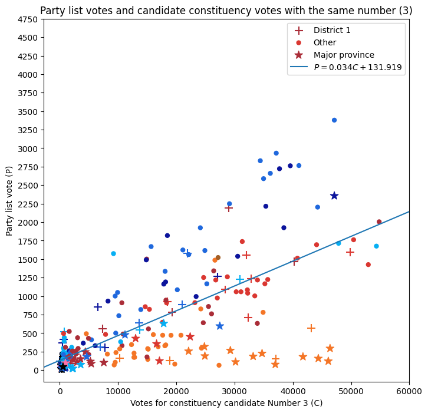

แกนนอนของ plot ข้างบนคือคะแนนของสส.เขตเบอร์ 3 ของแต่ละเขตเลือกตั้ง ส่วนแกนตั้งคือคะแนนบัญชีรายชื่อที่พรรคเป็นธรรมได้รับในเขตเดียวกัน ส่วนสัญลักษณ์อื่นๆมีดังนี้ครับ

- วงกลมคือเขตทั่วไป, เครื่องหมายบวกคือเขต 1, และดวงดาวคือเขตในจังหวัดใหญ่ที่มี GDP สูง (ประกอบด้วยกรุงเทพมหานคร, นนทบุรี, ปทุมธานี, ระยอง, ชลบุรี, สมุทรปราการ, สมุทรสาคร, นครปฐม, และพระนครศรีอยุธยา)
- สีแดง = เพื่อไทย; ส้ม = ก้าวไกล; ฟ้าอ่อน = ประชาธิปัตย์; น้ำเงิน = พลังประชารัฐ; และแดงม่วง = รวมไทยสร้างชาติ; ชมพู = ชาติไทยพัฒนา; น้ำตาล = ประชาชาติ

```
N major = 1
```

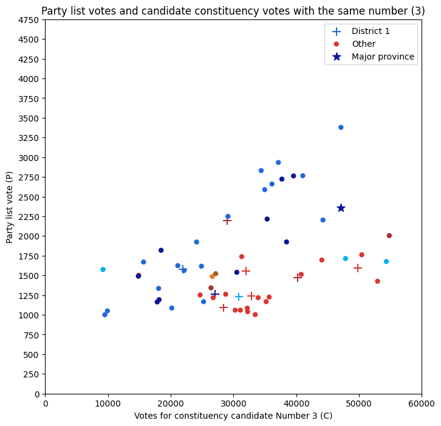

## เราจะอธิบายความสัมพันธ์นี้อย่างไรดี

คำอธิบายที่ตรงไปตรงมาที่สุดคือผู้ใช้สิทธิเลือกตั้งบางคนกาผิด กล่าวคือต้องการกาให้สส.เขตหมายเลข 3 แต่เผลอกาบัญชีรายชื่อหมายเลข 3 จุดบอดของคำอธิบายนี้คือทำไมคนที่เลือกสส.เขตแต่ละพรรคมีอัตรากาผิดที่แตกต่างกัน ทำไมอัตรากาผิดของก้าวไกลต่ำ เพื่อไทยกลางๆ และพลังประชารัฐ/ภูมิใจไทยสูงกว่าพรรคอื่นๆ [คำอธิบายอีกประการ](https://smiley159.github.io/Unveiling-Electoral-Deception/?fbclid=IwAR1vIpo-T-hMOfgXGwH_BniEq0FUHQc_MaCehqZoP-zeb3byc_5CgQ-HDrE)ที่คุณภูมิใจ ฉัตรไมตรีเคยวิเคราะห์คือการซื้อเสียง เพราะพรรคก้าวไกลน่าจะซื้อเสียงน้อยที่สุดในบรรดา 6 พรรคการเมืองใหญ่

ผมให้น้ำหนักคำอธิบายแรก (กาผิด) $60-65\%$ และคำอธิบายที่สอง (ซื้อเสียง) $30-35\%$ ผลสำรวจความนิยมต่อพรรคการเมืองช่วงก่อนเลือกตั้งชี้ชัดว่าก้าวไกลเป็นที่นิยมในหมู่โหวตเตอร์อายุ 18-30 ปีหรืออาศัยอยู่ในกรุงเทพและปริมณฑล ผมเชื่อว่าคนที่กลุ่มนี้น่าจะกาผิดน้อยกว่าผู้ใช้สิทธิเลือกตั้งกลุ่มอื่นๆและทราบแทบทุกคนว่าก้าวไกลปาร์ตี้ลิสต์เบอร์ 31

ณ จุดนี้ ผู้อ่านหลายคนอาจสงสัยว่าความนิยมพรรคมีผลแค่ไหน หักล้างคำอธิบายเรื่องการกาผิดและการซื้อเสียงได้มั้ย ผมว่า**ไม่ได้**

ลองเทียบบัญชีรายชื่อเขตที่พรรคจิ๋วได้คะแนนสูงสุดในบรรดา 400 เขตเทียบกับเขตอื่นๆในจังหวัดเดียวกันดูครับ ตัวอย่างเช่น พรรคเป็นธรรมได้คะแนนปาร์ตี้ลิสต์สูงมากในบางเขตของจังหวัดเหล่านี้ครับ

1. เพชรบูรณ์
2. กำแพงเพชร
3. นราธิวาส
4. สุรินทร์
5. บุรีรัมย์
6. อยุธยา
7. นครราชสีมา

| cons_id | party_id | party_list_vote | party_list_vote_percent | CandidateConst_vote | party_id_CandidateConst | status |
| --- | --- | --- | --- | --- | --- | --- |
| PNB_6 | 747 | 3379 | 3.60457 | 47118 | 743 | 0 |
| KPT_3 | 747 | 2933 | 3.10029 | 37149 | 743 | 0 |
| NWT_3 | 747 | 2830 | 3.51938 | 34411 | 743 | 0 |
| PNB_4 | 747 | 2765 | 3.19432 | 41039 | 743 | 0 |
| SRN_8 | 747 | 2762 | 3.02758 | 39558 | 709 | 0 |
| BRM_4 | 747 | 2722 | 3.31333 | 37706 | 709 | 0 |
| KPT_4 | 747 | 2660 | 2.72376 | 36132 | 743 | 0 |
| PNB_5 | 747 | 2588 | 2.84586 | 34971 | 743 | 0 |
| AYA_3 | 747 | 2356 | 2.18354 | 47117 | 709 | 2 |
| NMA_5 | 747 | 2249 | 2.20218 | 29118 | 743 | 0 |

```
N major = 0
```

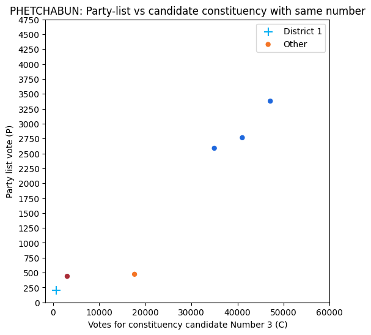

```
N major = 0
```

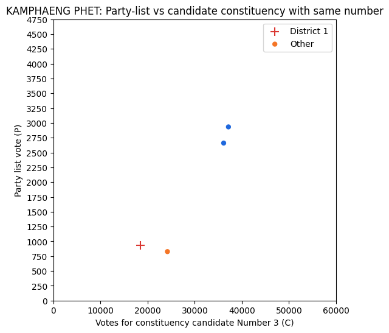

```
N major = 0
```

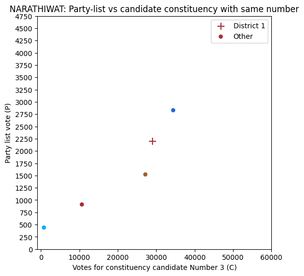

```
N major = 0
```

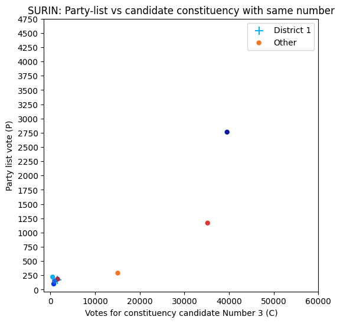

```
N major = 0
```

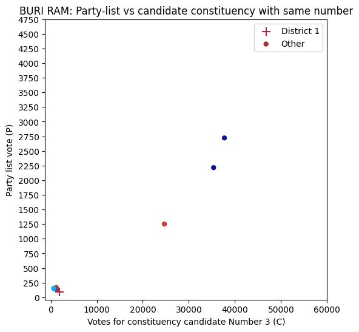

```
N major = 0
```

[figure not shown]

```
N major = 5
```

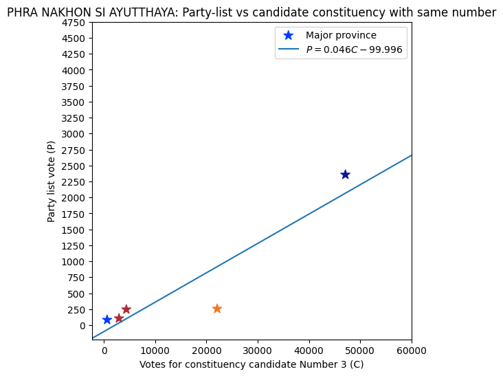

```
N major = 0
```

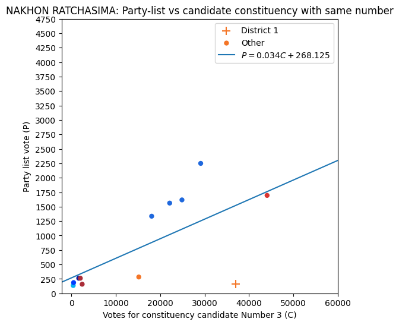

พรรคบัญชีรายชื่อหมายเลข 1-6 ทุกพรรคล้วนมีลักษณะเช่นที่ผมตั้งข้อสังเกตและรับอานิสงส์จากการกาผิด เอวังด้วยประการฉะนี้...